# Resource

# Predicting SAT Scores from Education Spending

## Purpose

In this project, we have explored the relationship between education spending and SAT scores. Government budgeting is often a hotly-debated topic and legislators want to ensure that increasing spending in certain areas actually has a measurable impact. It is important for legislators to understand how changes in budgeting will impact related outcomes. To address this issue, we will attempt to use machine learning to predict SAT scores using education spending. If our models are accurate, we could determine how proposed budget changes may impact SAT scores, an important metric for measuring student success.

## Exploratory Data Analysis

After collecting our data, we decided to use some simple map visualizations to understand and explore the data. We have created one map to visualize education spending by state and another map to visualize SAT scores by state. The purpose of these visualizations is to show that there is significant variation in the variables we are exploring in this project. In the rest of our report we will continue to investigate these variables furthere and hope to draw some interesting conclusions!

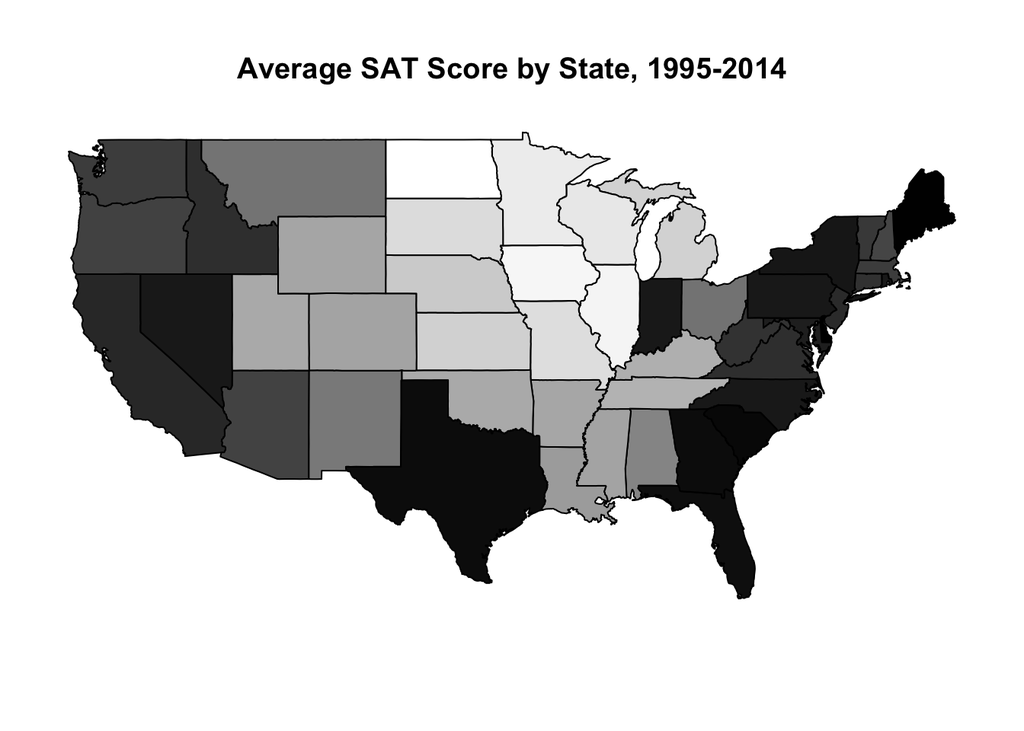

This map of the United States shows the average SAT scores by state. The darker the state the lower the average score over 1995-2014 and vice versa. The area with the lowest scores is the District of Columbia, while the area with the highest scores is North Dakota.

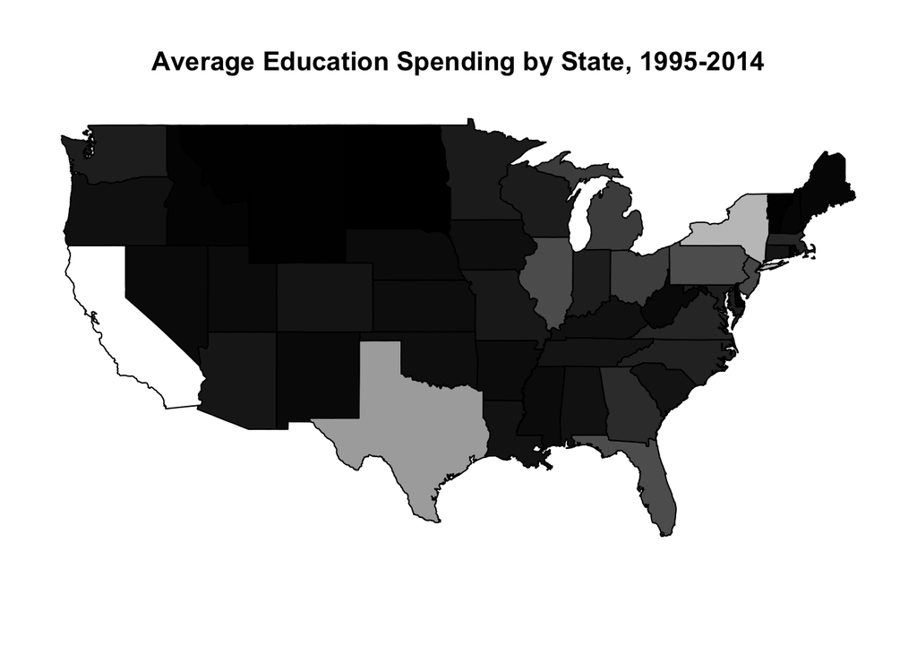

## Questions

**Question 1:** Is there a relationship between the amount of money spent on education and the average SAT score by state?

**Quesiton 2:** Can we predict the average SAT scores based on the amount of school spending?

## Data

### Spending Data

To explore this topic, we used data from the National Center for Education Statistics. We gathered data related to education expenditures from 1990-2014 and average SAT scores from 1995-2014. There was an amount of cleaning and organizing that occured in both Excel and R to make the data usable. The dataframe that contained SAT scores was originally constructed with both column headers and row headers; R was not smart enough to tell the difference between the two, so it was necessary to reconstruct the csv file before importing to R. Once both data frames were imported, we combined the yearly spending data into one dataframe. This dataframe had spending data from 1995-2014 for all 50 states, plus the District of Columbia and the national total.

Since our goal was to build a predictive model that could accurately predict SAT scores based on the amount of money available for education, we needed to think about the spending power of a dollar. Our dataset spanned over 20 years, and a dollar in 1995 could buy considerably more than a dollar in 2014. To account for this discrepancy, we multiplied the mean amount of money spent by the inflation rate between that year and year 2014. This normalized the mean amount for each year so that the spending power is the same for each year. Bellow is the final spending dataset used:

```
##           State Number.of.districts   Minimum         Maximum         Mean
## 1 United States              15,553       $0  $9,452,532,000  $18,121,987
## 2       Alabama                 127 3,664,000     261,093,000   26,404,425
## 3        Alaska                  54   721,000     386,331,000   22,292,907
## 4       Arizona                 228    18,000     353,292,000   17,790,697
## 5      Arkansas                 328   632,000     158,337,000    6,570,229
## 6    California               1,082    82,000   3,708,071,000   27,816,576
##   year
## 1 1995
## 2 1995
## 3 1995
## 4 1995
## 5 1995
## 6 1995
```

### SAT Score Data

The SAT score data was organized by year, then by section of the test. Years 1995 and 2000 had a mathematics score and critical reading score; the other years listed, 2005, 2010, 2013, 2014 had an addition critical writing score. Since this new score was added, it was necessary to standardize the scores. We did this by first adding together the scores for each category of the test for each year to get a total score for each year. We then divided the total score across all sections by the total amount of possible points. This bounded all SAT scores between 0 and 1. The total amount of points varied; in years 1995 and 2000 the total possible amount of points earned was 1600, all other years the total possible amount of points earned was 2400. Our final, workable SAT score dataset looked like this:

```
##           State year    score
## 1 United States 1995 0.633125
## 2       Alabama 1995 0.701875
## 3        Alaska 1995 0.646250
## 4       Arizona 1995 0.653750
## 5      Arkansas 1995 0.697500
## 6    California 1995 0.628750
```

We then merged the two dataframes, joining on state and year. The spending data had more years than the SAT score data; years that had missing data points were dropped.

Here is our final data frame after warngling, standardizing, and combining both spending and SAT score data frames:

```
##     State year Number.of.districts Minimum   Maximum     Mean     score
## 1 Alabama 1995                 127 5691658 405581866 41016634 0.7018750
## 2 Alabama 2000                 128 7786867 551756733 53738214 0.6956250
## 3 Alabama 2005                 131 6607702 661439354 54638425 0.7045833
## 4 Alabama 2010                 132 6317688 631356264 62901272 0.6762500
## 5 Alabama 2014                 136 5017000 580513000 56261816 0.6733333
## 6  Alaska 1995                  54 1120001 600126575 34629802 0.6462500
```

## Question 1:

Is there a relationship between the amount of money spent on education and the average SAT score by state?

Linear Regression: Statistical analysis

To find a relationship between the mean amount of money spent at schools (predictor variable) and the average SAT score (responsive variable), required further exploration of the data. We could see a linear relationship between the two variables.

We then looked to see if the average SAT scores had a normal distribution; we did this by creating a density plot, shown below.

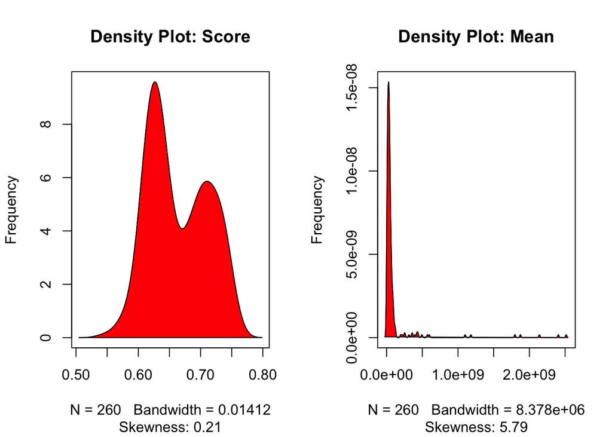

Finally, we had enough information to build and use a linear model to measure the correlation between or predictor and response variables. Below is a summary of our regression.

```
##
## Call:
## lm(formula = score ~ Mean, data = all.data)
##
## Residuals:
##      Min       1Q   Median       3Q      Max
## -0.11890 -0.03822 -0.01413  0.03960  0.08915
##
## Coefficients:
##               Estimate Std. Error t value Pr(>|t|)
## (Intercept)  6.673e-01  3.021e-03 220.891  < 2e-16 ***
## Mean        -3.823e-11  9.086e-12  -4.208 3.56e-05 ***
## ---
## Signif. codes:  0 '***' 0.001 '**' 0.01 '*' 0.05 '.' 0.1 ' ' 1
##
## Residual standard error: 0.04622 on 258 degrees of freedom
## Multiple R-squared:  0.06423,    Adjusted R-squared:  0.0606
## F-statistic: 17.71 on 1 and 258 DF,  p-value: 3.558e-05
```

Our small p-value (.00003558) and relatively high t-value indicate we can safely accept the alternate hypothesis. Findings show there is a relationship between the average amount of money spent and average SAT scores. Below are some predictions made with our linear model, not very accurate:

[figure not shown]

## Question 2:

Can we predict the average SAT scores based on the amount of school spending?

Now that we have proven that there is a significant relationship between education spending and SAT scores, we will attempt to answer our second question, which is related to predicting SAT scores with spending data. In order to address this question, we will be breaking up our training and testing data based on the year. We will define our training data as data from 1995, 2000, 2005, and 2010. Our testing data will be data from 2014. In summary, we will be trying to predict the 2014 SAT scores using 2014 spending data with a model trained on data from 1995, 2000, 2005, and 2010.

For our classifiers, we have chosen Lasso, Elastic Net, and RidgeRegression. These three classifiers were selected because they are well suited for regression rather than classification. Lasso and Elastic Net are recommended for datasets with few important features, while RidgeRegression is well suited for datasets with many important features. Since we really didn’t have much of an idea how many or which features would be important, we chose to cover our bases by selecting these three classifiers. We selected our classifiers based on this estimator selection guide from [Scikit Learn](http://scikit-learn.org/stable/tutorial/machine_learning_map/).

We used Python to run our machine learnings, the Jupyter notebook in in our Github repository contains all of the code. Below are images from the results of our machine learning analysis.

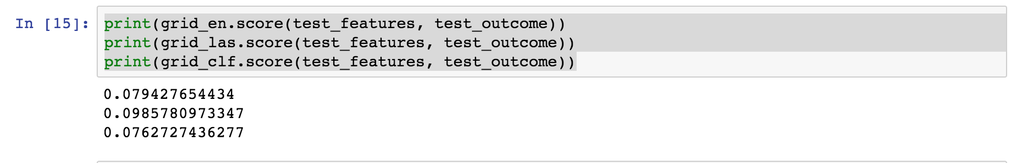

Accuracy results from our three models

### Predicted SAT Score Distribution vs. Actual SAT Score Distribution

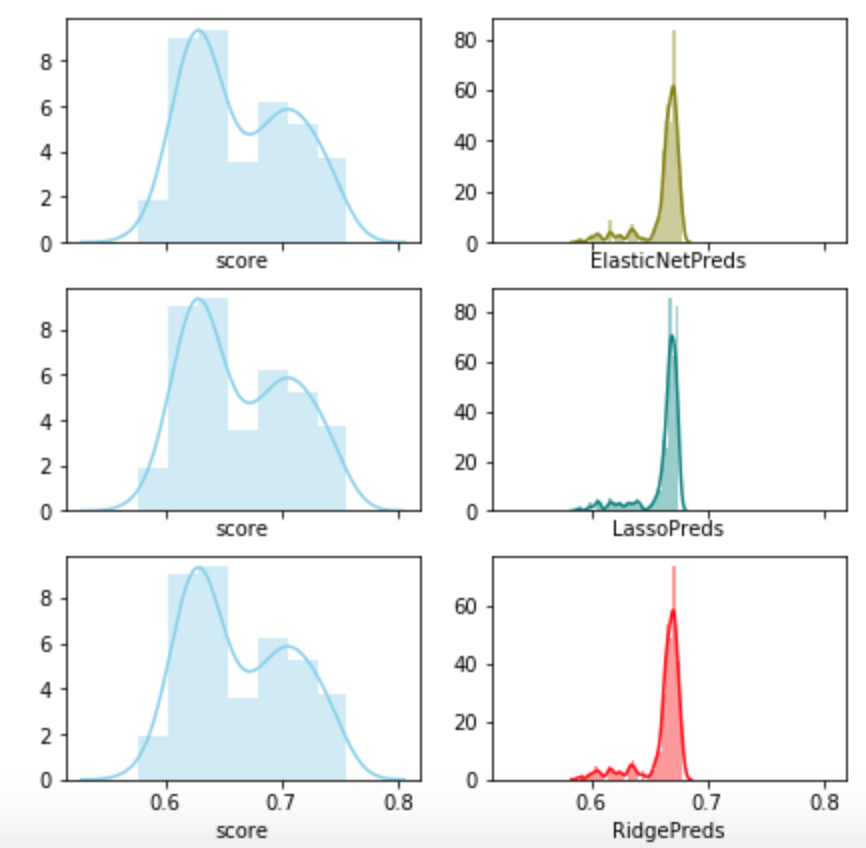

### Lasso Predicted Scores vs. Actual SAT Scores

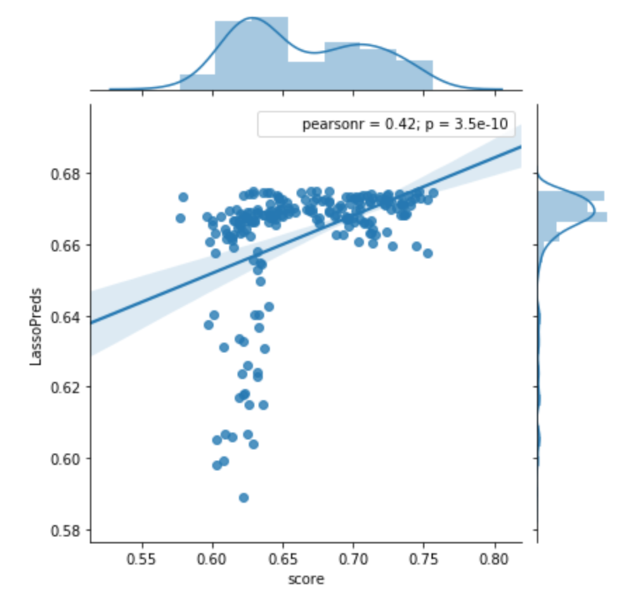

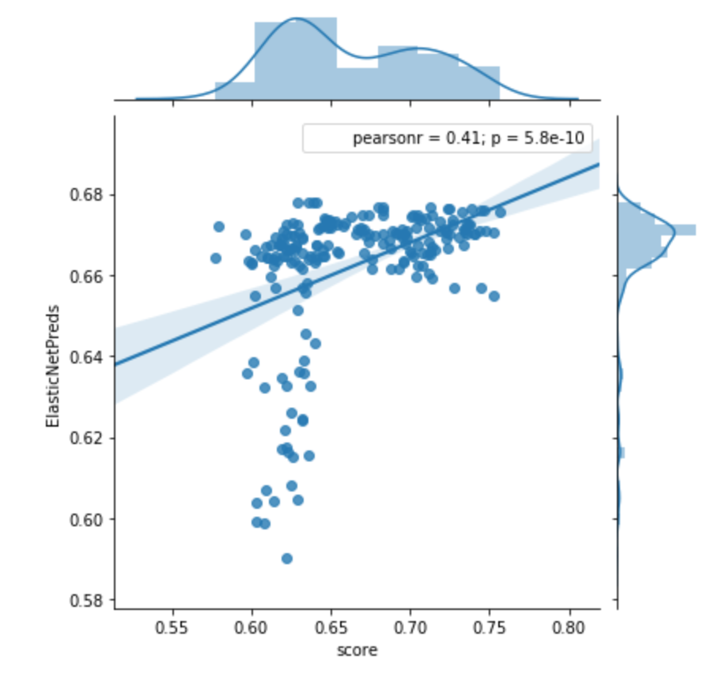

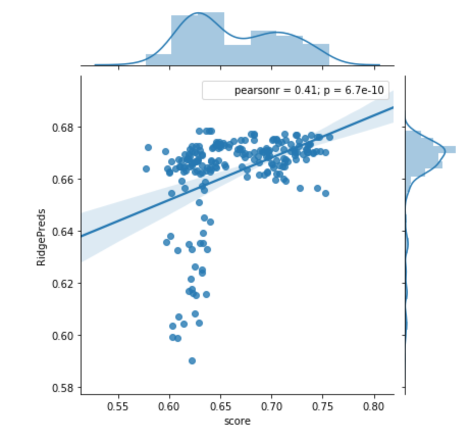

During our machine learning process, we built a pipeline and used grid search for cross-validation. Our models were not successful at predicting SAT scores, the best model was only 9.8% accurate.

In conclusion, we have shown that there is a significant relationship between education spending and SAT scores, but that spending amount alone is not a strong predictor of test scores. This conclusion makes sense, there are many factors, including education spending, that likely have an impact on student performance on standardized tests. Some other factors that we would want to include to better predict test scores include socioeconomic status, family life, student location, and advancement of technology. There is also a point to be made about SAT scores and how they may not be the best measure of student performance or success. It is certainly possible to be a great student and test poorly on the SAT. In conclusion, this was a great exercise for us to apply statistics and machine learning to learn more about how education spending and standardized test performance are related.